# El Paso Wasterwater Surveillance Time Series Analysis

April 19, 2022

**Analysis Objective**: Process, analyze the time series data from WW Surveillance collected from El Paso, Texas 1. Process the data from multiple excel sheets to a combined dataset (long format)

2. Exploratory analysis of time series figures with WW concentration
3. Exploratory analysis of time series figures with COVID reported case data
4. Cross-correlation between the case and WW concentration - see this link for reading https://online.stat.psu.edu/stat510/lesson/8/8.2

```r
#install.packages("xts"); install.packages("dygraphs"); install.packages("feasts")
library(feasts)
library(tsibble)
library(lubridate)
library(ggplot2)
library(dplyr)
library(viridis)
library(lubridate)
library(ggExtra)
library(tidyr)
library(lubridate)
library(dygraphs)
library(xts)
library(tidyverse)
library(readxl)
library(writexl)
library(janitor)
library(ggpubr)
```

### Data processing

Read in raw data and export an organized dataset. Time framework is between 6/22/2020 and 3/2/2022.

```r
### Combine daily data into one dataset
#sheet names indicating data collection date
sheet_names <- excel_sheets("WW_data/WeeklyReports_ElPaso_Mezzari_2022.xlsx")
sheet_names
## read in and combine daily data first
dat <- lapply(sheet_names[-c(36,47,48)], function(x) { as.data.frame(read_excel("WW_data/WeeklyReports_ElPaso_Mezzari_2022.xlsx", sheet = x)) } )
comb.dat <-bind_rows(dat)[,-c(14,15)] %>% filter(`WWTP Site` %in% c("Fred Hurvey","Haskell","John T. Hickerson","Roberto Bustamante")) %>%
  rename(`Copies per L waste water (N1)`=`Copies/ L of wastewater (N1)`,
         `Copies per L waste water (N2)`=`Copies/ L of wastewater (N2)`)
## read in cumulative data sheet
# sheet 47: Cumulative Maresso from 2020 and 2021
FH.dat <- read_excel("WW_data/WeeklyReports_ElPaso_Mezzari_2022.xlsx", sheet=47, range="A6:I19") %>% mutate(`WWTP Site`="Fred Hurvey", `AVG Flowrate (MGD)`=6.05,`Date Collected`=as.Date(substr(`Sample Name`,4,11), format="%m/%d/%y"))
HS.dat <- read_excel("WW_data/WeeklyReports_ElPaso_Mezzari_2022.xlsx", sheet=47, range="K6:S19") %>% mutate(`WWTP Site`="Haskell", `AVG Flowrate (MGD)`=13.16,`Date Collected`=as.Date(substr(`Sample Name`,4,11), format="%m/%d/%y"))
JT.dat <- read_excel("WW_data/WeeklyReports_ElPaso_Mezzari_2022.xlsx", sheet=47, range="U6:AC18") %>% mutate(`WWTP Site`="John T. Hickerson",`AVG Flowrate (MGD)`=7.89,`Date Collected`=as.Date(substr(`Sample Name`,4,11), format="%m/%d/%y"))
RB.dat <- read_excel("WW_data/WeeklyReports_ElPaso_Mezzari_2022.xlsx", sheet=47, range="K6:S19") %>% mutate(`WWTP Site`="Roberto Bustamante",`AVG Flowrate (MGD)`=28.75,`Date Collected`=as.Date(substr(`Sample Name`,4,11), format="%m/%d/%y"))

# sheet 48: Cumulative CMMR from 2020 (6/22/2020 - 11/4/2020) - different format
# need to reformat the data
cmmr <- read_excel("WW_data/WeeklyReports_ElPaso_Mezzari_2022.xlsx", sheet=48,range="A2:G99") %>%
  mutate(`WWTP Site`=ifelse(`Sample Point WWTP RAW`=="FH", "Fred Hurvey",
                            ifelse(`Sample Point WWTP RAW`=="HS", "Haskell",
                                   ifelse(`Sample Point WWTP RAW`=="JT", "John T. Hickerson", "Roberto Bustamante"))),
         `Sample ID`=paste(`Sample Point WWTP RAW`, substr(`EP ID`, 2, 9), sep=" "),
         `Sample Name`=paste0(Concat, "/20"),
         `N1 Cт`=`AVG N1`, `N2 CT`=`AVG N2`)

# combine all data together
dat.processed <- bind_rows(comb.dat, FH.dat, HS.dat, JT.dat, RB.dat, cmmr[,c(2,4,8:12)])
# save the processed data
writexl::write_xlsx(dat.processed, "WeeklyReports_ElPaso_Mezzari_2022_Processed.xlsx")
```

```r
# read in processed WWTP data
organized.data <- read_excel("WeeklyReports_ElPaso_Mezzari_2022_Processed.xlsx") %>% mutate(Date=as.Date(`Date Collected`))
sample_n(organized.data, 10) %>% knitr::kable()
```

| WWTP Site | Date Collected | Sample ID | Sample Name | N1 Cт | Quantity for 10 ul volume into PCR (N1) | Copies per L waste water (N1) | N2 CT | Quantity for 10 ul volume into PCR (N2) | Copies per L waste water (N2) | AVG Flowrate (MGD) | Copies/MGD (N1) | Copies/MGD (N2) | CMMR ID | Date |
| --- | --- | --- | --- | --- | --- | --- | --- | --- | --- | --- | --- | --- | --- | --- |
| Roberto Bustamante | 2021-11-09 | RB 21-34778 | RB 11/09/21 | 31.30000 | 586.0 | 390666.667 | 33.20000 | 199.6 | 133066.67 | 26.52 | 39218683245664 | 13358445692550 | NA | 2021-11-09 |
| Roberto Bustamante | 2021-02-24 | NA | HS 02/24/21 | 33.50000 | 119.1 | 79400.000 | 37.70000 | 7.8 | 5200.00 | 28.75 | 3955391931467 | 259043300298 | NA | 2021-02-24 |
| Roberto Bustamante | 2020-07-15 | RB 20-24432 | RB 07/1520 | NA | NA | NA | NA | NA | NA | NA | NA | NA | WW 09 | 2020-07-15 |
| Roberto Bustamante | 2020-10-28 | RB 20-36324 | RB 10/2820 | 34.82450 | NA | NA | 36.52100 | NA | NA | NA | NA | NA | WW 90 | 2020-10-28 |
| Fred Hurvey | 2021-08-25 | FH 21-25118 | FH 8/25/21 | 33.70000 | 100.2 | 66800.000 | 36.70000 | 15.5 | 10333.33 | 5.86 | 1481791878286 | 229219302529 | NA | 2021-08-25 |
| John T. Hickerson | 2021-09-22 | JT 21-28403 | JT 9/22/21 | 34.10000 | 75.0 | 50000.000 | 36.00000 | 26.4 | 17600.00 | 7.07 | 1338143071300 | 471026361098 | NA | 2021-09-22 |
| Fred Hurvey | 2021-06-09 | FH 21-16073 | FH 6/9/21 | 39.20000 | 1.7 | 1133.333 | NA | NA | 0.00 | 5.86 | 25140181568 | 0 | NA | 2021-06-09 |
| Roberto Bustamante | 2021-08-25 | RB 21-25120 | RB 8/25/21 | 32.80000 | 191.4 | 127600.000 | 35.10000 | 49.6 | 33066.67 | 26.52 | 12809651831434 | 3319533598950 | NA | 2021-08-25 |
| Fred Hurvey | 2021-09-22 | FH 21-28404 | FH 9/22/21 | 32.80000 | 197.9 | 131933.333 | 35.70000 | 32.5 | 21666.67 | 5.86 | 2926612901326 | 480621118207 | NA | 2021-09-22 |
| Haskell | 2020-07-29 | HS 20-25912 | HS 07/2920 | 38.96698 | NA | NA | 41.51409 | NA | NA | NA | NA | NA | WW 11 | 2020-07-29 |

#### Explorary analysis with the the WW concentration

```r
#subset the data by WWTP
#sub<- organized.data[ which(organized.data$`WWTP Site`=='Fred Hurvey') ,]
FH<-subset(organized.data , `WWTP Site`=="Fred Hurvey", select = c("Date", "N1 Cт", "N2 CT")) %>% na.omit()
Has<-subset(organized.data , `WWTP Site`=="Haskell", select = c("Date", "N1 Cт", "N2 CT")) %>% na.omit()
Jth<-subset(organized.data , `WWTP Site`=="John T. Hickerson", select = c("Date", "N1 Cт", "N2 CT")) %>% na.omit()
Rb<-subset(organized.data , `WWTP Site`=="Roberto Bustamante", select = c("Date", "N1 Cт", "N2 CT")) %>% na.omit()
```

For the figures below I modified the following 1) legends shortened to “N1” and “N2” and 2) no need to plot all dates - I modified to print every 4 weeks in the label.

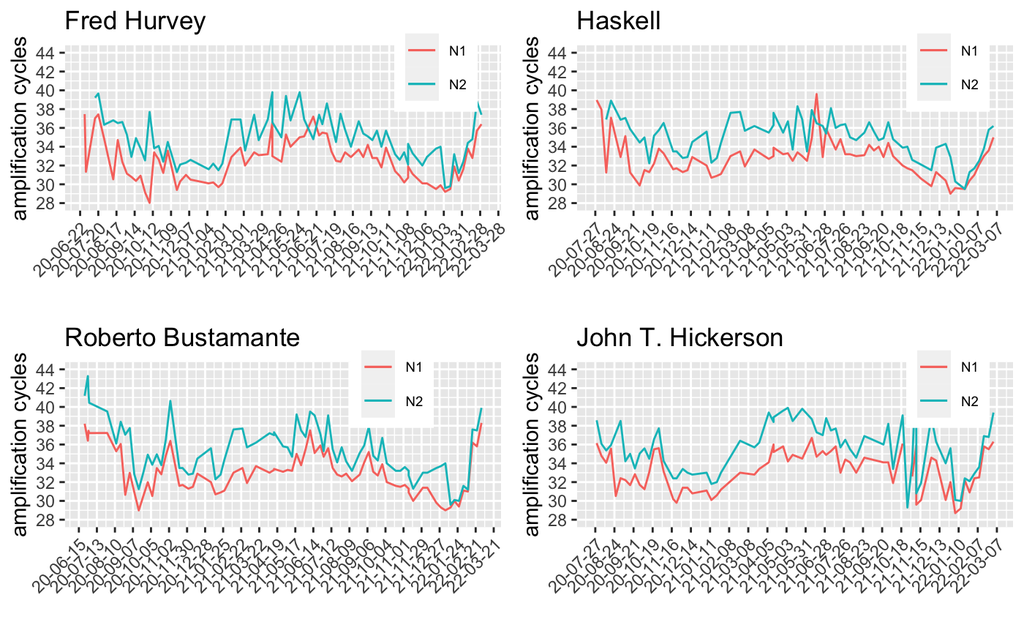

```r
# convert to xts objects for plotting
# FH.ts <- xts(x = FH, order.by = FH$Date)
# Has.ts <- xts(x = Has, order.by = Has$Date)
# Jth.ts <- xts(x = Jth, order.by = Jth$Date)
# Rb.ts <- xts(x = Rb, order.by = Rb$Date)
#plot.Rb<-dygraph(Rb.ts,main="Roberto Bustamante")

break.vec <- c(seq(from = as.Date("2021-04-07"), to = as.Date("2022-03-02"), by = "week"))
## plot the N1 and N2 CT value by WWTP
# Fred Hurvey
p.F <- ggplot(FH, aes(x=Date))+
            geom_line(aes(y = `N1 Cт`, colour = "N1")) +
              geom_line(aes(y=`N2 CT`,colour="N2"))+
  scale_y_continuous(breaks = scales::pretty_breaks(n = 10),limits = c(28,44))
### here instead of print every week,
a <-p.F+labs(title="Fred Hurvey",x ="", y = "amplification cycles",colour=NULL)+
  scale_x_date(breaks = break.vec, date_breaks="4 weeks", date_labels = "%y-%m-%d")+
  theme(legend.position=c(0.85,0.9),legend.text = element_text(size=7),
        axis.text.x =element_text (angle=45,hjust=1))

# Haskell
p.H<-ggplot(Has, aes(x=Date))+
  geom_line(aes(y = `N1 Cт`, colour = "N1")) +
  geom_line(aes(y=`N2 CT`,colour="N2"))+scale_y_continuous(breaks = scales::pretty_breaks(n = 10),limits = c(28,44))

b<-p.H+labs(title="Haskell",x ="", y = "amplification cycles",colour=NULL)+
  scale_x_date(breaks = break.vec, date_breaks="4 weeks", date_labels = "%y-%m-%d")+
  theme(legend.position=c(0.85,0.9),legend.text = element_text(size=7),axis.text.x =element_text (angle=45,hjust=1))

# Roberto Bustamante
p.R<-ggplot(Rb, aes(x=Date))+
  geom_line(aes(y = `N1 Cт`, colour = "N1")) +
  geom_line(aes(y=`N2 CT`,colour="N2"))+
  scale_y_continuous(breaks = scales::pretty_breaks(n = 10),limits = c(28,44))

c<-p.R+labs(title="Roberto Bustamante",x ="", y = "amplification cycles",colour=NULL)+
  scale_x_date(breaks = break.vec, date_breaks="4 weeks", date_labels = "%y-%m-%d")+ theme(legend.position=c(0.75,0.9),legend.text = element_text(size=7),axis.text.x =element_text (angle=45,hjust=1))

# John T. Hickerson
p.J<-ggplot(Jth, aes(x=Date))+
  geom_line(aes(y = `N1 Cт`, colour = "N1")) +
  geom_line(aes(y=`N2 CT`,colour="N2"))+
  scale_y_continuous(breaks = scales::pretty_breaks(n = 10),limits = c(28,44))

d<-p.J+labs(title="John T. Hickerson",x ="", y = "amplification cycles",colour=NULL)+
  scale_x_date(breaks = break.vec, date_breaks="4 weeks", date_labels = "%y-%m-%d")+
  theme(legend.position=c(0.85,0.9), legend.text = element_text(size=7),axis.text.x =element_text (angle=45,hjust=1))

ggarrange(a,b,c,d, ncol = 2, nrow = 2)
```

### Time series analysis with the reported number of cases

Looking I see the variable names still need additional cleaning.

**Case data cleaning**

```r
# Convert data from wide to long
myData.df <- gather(myData.df, WWTP, CaseRate, `NW/John T.`:`Bustamante`) %>% mutate(CaseRate=as.numeric(CaseRate))
```

[output not shown]

**Time period: 3/22/2021 - 1/26/2022**

| Date | WWTP | CaseRate |
| --- | --- | --- |
| 2021-08-14 | Haskell | 4.269824 |
| 2021-06-16 | NW/John T. | 3.774183 |
| 2021-03-25 | NW/John T. | 17.361240 |
| 2021-06-11 | Hervey | 0.000000 |
| 2021-09-30 | Haskell | 5.693099 |
| 2021-09-21 | Hervey | 19.418847 |
| 2021-09-30 | Bustamante | 18.246261 |
| 2022-01-18 | NW/John T. | 261.928300 |
| 2021-08-27 | Haskell | 7.116374 |
| 2021-06-13 | Bustamante | 0.912313 |

For the figures, can we over lay the WW time series and the case data (perhaps case data y-axis on the right), to see how the trends correlate? Looks like we need to do this for each facility (i.e., Fred Hurvey, Haskell etc)

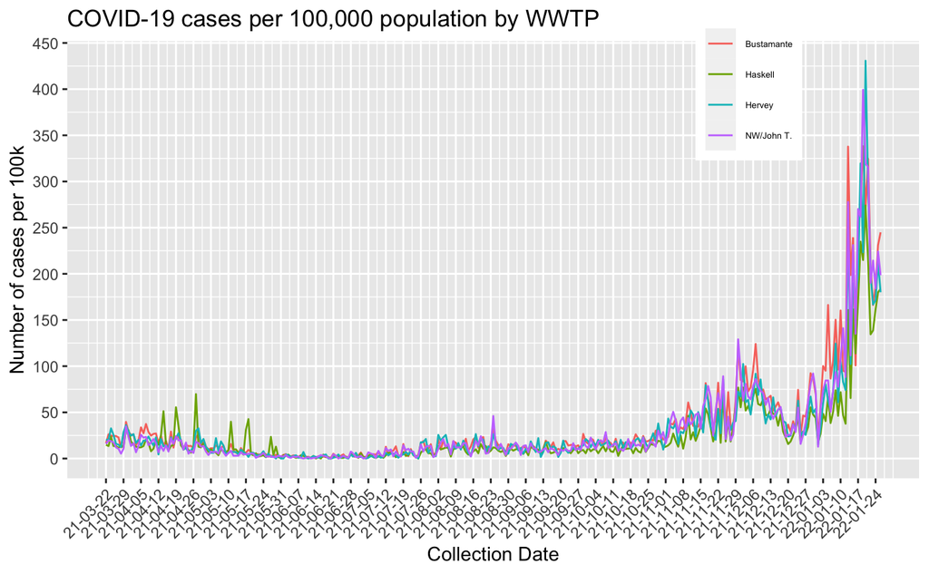

```r
break.vec <- c(seq(from = as.Date("2021-03-22"), to = as.Date("2022-1-27"),by = "week"))
timeseries.case <- ggplot(myData.df, aes(x=Date))+
  geom_line(aes(y = CaseRate, color = WWTP))+scale_y_continuous(breaks = scales::pretty_breaks(n = 10))+
  labs(title="COVID-19 cases per 100,000 population by WWTP",x ="Collection Date", y = "Number of cases per 100k", color=NULL)+
  scale_x_date(breaks = break.vec, date_labels = "%y-%m-%d")+
  theme(legend.position=c(0.8,0.9),legend.text = element_text(size=5),axis.text.x =element_text (angle=45,hjust=1))
timeseries.case
```

```r
#ggarrange(a,b,c,d,timeseries.case, ncol = 3, nrow = 2)
```

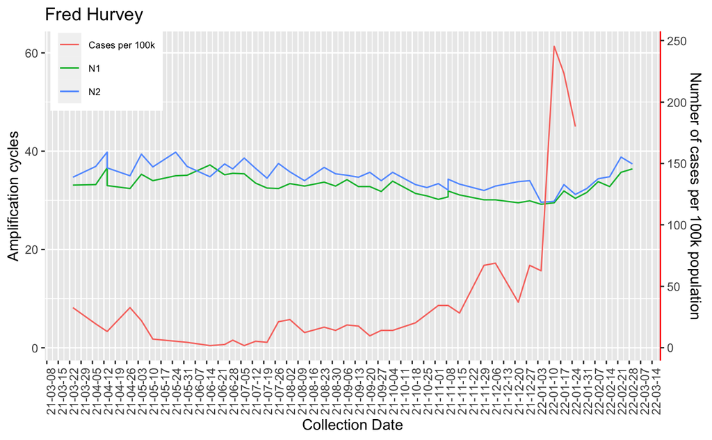

```r
## Fred Hurvey
FH_dt <- left_join(FH, subset(myData.df, myData.df$WWTP=="Hervey"), by="Date") %>% filter(Date >= as.Date("2021-03-24"))
coeff <- 4
overlay.F <- ggplot(FH_dt, aes(x=Date))+
  geom_line(aes(y = `N1 Cт`, colour = "N1")) +
  geom_line(aes(y=`N2 CT`,colour="N2"))+
  geom_line(aes(y = CaseRate/coeff, x=Date, color = "Cases per 100k"))+
  labs(title="Fred Hurvey",x ="Collection Date", y = "Amplification cycles",colour=NULL)+
  scale_y_continuous(   # Custom the Y scales:
    name = "Amplification cycles", # Features of the first axis
    sec.axis = sec_axis(trans=~.*coeff, name="Number of cases per 100k population"))+ # Add a second axis and specify its features
  scale_x_date(breaks = break.vec, date_breaks="week", date_labels = "%y-%m-%d")+
  theme(legend.position=c(0.1,0.9),legend.text = element_text(size=7),
        axis.text.x =element_text (angle=90,hjust=1))+
  theme(axis.line.y.right = element_line(color = "red"))
overlay.F
```

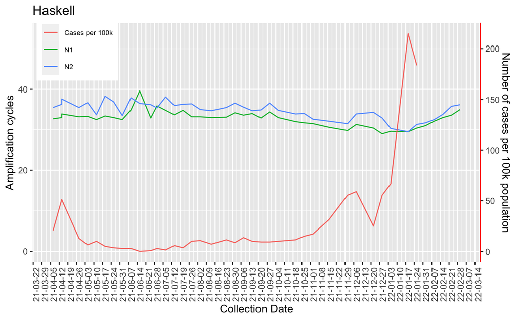

```r
## Haskell
HS_dt <- left_join(Has, subset(myData.df, myData.df$WWTP=="Haskell"), by="Date") %>% filter(Date >= as.Date("2021-04-07"))
coeff <- 4
overlay.H <- ggplot(HS_dt, aes(x=Date))+
  geom_line(aes(y = `N1 Cт`, colour = "N1")) +
  geom_line(aes(y=`N2 CT`,colour="N2"))+
  geom_line(aes(y = CaseRate/coeff, x=Date, color = "Cases per 100k"))+
  labs(title="Haskell",x ="Collection Date", y = "Amplification cycles",colour=NULL)+
  scale_y_continuous(   # Custom the Y scales:
    name = "Amplification cycles", # Features of the first axis
    sec.axis = sec_axis(trans=~.*coeff, name="Number of cases per 100k population"))+ # Add a second axis and specify its features
  scale_x_date(breaks = break.vec, date_breaks="week", date_labels = "%y-%m-%d")+
  theme(legend.position=c(0.1,0.9),legend.text = element_text(size=7),
        axis.text.x =element_text (angle=90,hjust=1))+
  theme(axis.line.y.right = element_line(color = "red"))
overlay.H
```

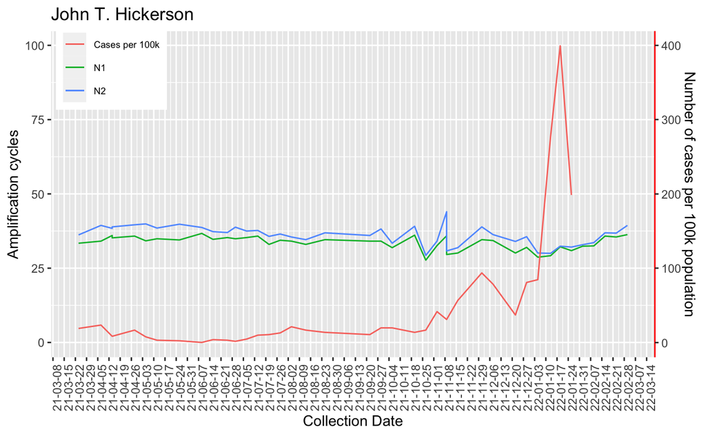

```r
## John T.
JT_dt <- left_join(Jth, subset(myData.df, myData.df$WWTP=="NW/John T."), by="Date") %>% filter(Date >= as.Date("2021-03-24"))
coeff <- 4
overlay.J <- ggplot(JT_dt, aes(x=Date))+
  geom_line(aes(y = `N1 Cт`, colour = "N1")) +
  geom_line(aes(y=`N2 CT`,colour="N2"))+
  geom_line(aes(y = CaseRate/coeff, x=Date, color = "Cases per 100k"))+
  labs(title="John T. Hickerson",x ="Collection Date", y = "Amplification cycles",colour=NULL)+
  scale_y_continuous(   # Custom the Y scales:
    name = "Amplification cycles", # Features of the first axis
    sec.axis = sec_axis(trans=~.*coeff, name="Number of cases per 100k population"))+ # Add a second axis and specify its features
  scale_x_date(breaks = break.vec, date_breaks="week", date_labels = "%y-%m-%d")+
  theme(legend.position=c(0.1,0.9),legend.text = element_text(size=7),
        axis.text.x =element_text (angle=90,hjust=1))+
  theme(axis.line.y.right = element_line(color = "red"))
overlay.J
```

[figure not shown]

```r
## Roberto Bustamante
RB_dt <- left_join(Rb, subset(myData.df, myData.df$WWTP=="Bustamante"), by="Date") %>% filter(Date >= as.Date("2021-03-24"))
coeff <- 4
overlay.R <- ggplot(RB_dt, aes(x=Date))+
  geom_line(aes(y = `N1 Cт`, colour = "N1")) +
  geom_line(aes(y=`N2 CT`,colour="N2"))+
  geom_line(aes(y = CaseRate/coeff, x=Date, color = "Cases per 100k"))+
  labs(title="John T. Hickerson",x ="Collection Date", y = "Amplification cycles",colour=NULL)+
  scale_y_continuous(   # Custom the Y scales:
    name = "Amplification cycles", # Features of the first axis
    sec.axis = sec_axis(trans=~.*coeff, name="Number of cases per 100k population"))+ # Add a second axis and specify its features
  scale_x_date(breaks = break.vec, date_breaks="week", date_labels = "%y-%m-%d")+
  theme(legend.position=c(0.1,0.9),legend.text = element_text(size=7),
        axis.text.x =element_text (angle=90,hjust=1))+
  theme(axis.line.y.right = element_line(color = "red"))
overlay.R
```

### Correlation analysis

#### Correlation analysis of Hasketll and N1

```r
#correlation analysis:Haskell and N1 CT
stackoverflow_HN1 <- HS_dt %>%
  dplyr::select(Date,`N1 Cт`, CaseRate)
stackoverflow_HN1<-stackoverflow_HN1[complete.cases(stackoverflow_HN1),]#cleaning data: delete NA

stackOverflowts <- ts(data = stackoverflow_HN1[, c("CaseRate","N1 Cт")], # selecting 2 variables
                       start = c(2021, 04), # start date
                       end = c(2022, 1), # end date
                       frequency = 52)

par(mfrow = c(2, 2))
# acf Haskell time series
stackOverflowts[, c("CaseRate")] %>%
  acf(lag.max = 300,
      main = "Autocorrelation Plot - Haskell")

# pacf Haskell time series
stackOverflowts[, c("CaseRate")] %>%
  pacf(lag.max = 300,
       main = "Partial Autocorrelation Plot - Haskell")
```

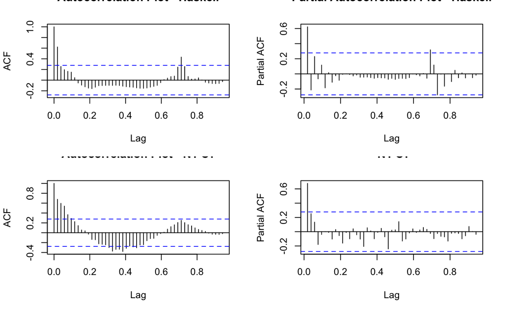

```r
# acf N1 Cт time series
stackOverflowts[, c("N1 Cт")] %>%
  acf(lag.max = 300,
      main = "Autocorrelation Plot - N1 Cт")

# pacf N1 Cт time series
stackOverflowts[, c("N1 Cт")] %>%
  pacf(lag.max = 300,
       main = " N1 Cт")
```

```r
#correlation analysis: Bustamante and N1 CT
stackoverflow_RN1 <- RB_dt %>%
  dplyr::select(Date,`N1 Cт`, CaseRate)

stackoverflow_RN1<-stackoverflow_RN1[complete.cases(stackoverflow_RN1),]#cleaning data:delete NA
stackOverflowts1 <- ts(data = stackoverflow_RN1[, c("CaseRate","N1 Cт")], # selecting 2 variables
                      start = c(2021, 04), # start date
                      end = c(2022, 1), # end date
                      frequency = 52)

par(mfrow = c(2, 2))
# acf Bustamante time series
stackOverflowts1[, c("CaseRate")] %>%
  acf(lag.max = 300,
      main = "Autocorrelation Plot - Bustamante")

# pacf  Bustamante time series
stackOverflowts1[, c("CaseRate")] %>%
  pacf(lag.max = 300,
       main = "Partial Autocorrelation Plot - Bustamante")
```

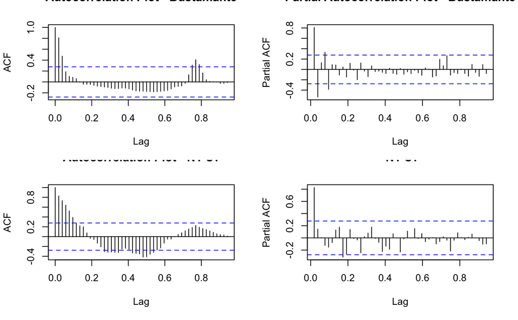

```r
# acf N1 Cт time series
stackOverflowts1[, c("N1 Cт")] %>%
  acf(lag.max = 300,
      main = "Autocorrelation Plot - N1 Cт")

# pacf N1 Cт time series
stackOverflowts1[, c("N1 Cт")] %>%
  pacf(lag.max = 300,
       main = " N1 Cт")
```

```r
#correlation analysis:  Hervey and N1 CT
stackoverflow_HEN1 <- FH_dt %>%
  dplyr::select(Date,`N1 Cт`, CaseRate)
stackoverflow_HEN1<-stackoverflow_HEN1[complete.cases(stackoverflow_HEN1),]#cleaning data: delete NA

stackOverflowts2 <- ts(data = stackoverflow_HEN1[, c("CaseRate","N1 Cт")], # selecting 2 variables
                       start = c(2021, 04), # start date
                       end = c(2022, 1), # end date
                       frequency = 52)

par(mfrow = c(2, 2))
# acf Hervey time series
stackOverflowts2[, c("CaseRate")] %>%
  acf(lag.max = 300,
      main = "Autocorrelation Plot - Hervey")

# pacf  Hervey time series
stackOverflowts2[, c("CaseRate")] %>%
  pacf(lag.max = 300,
       main = "Partial Autocorrelation Plot - Hervey")
```

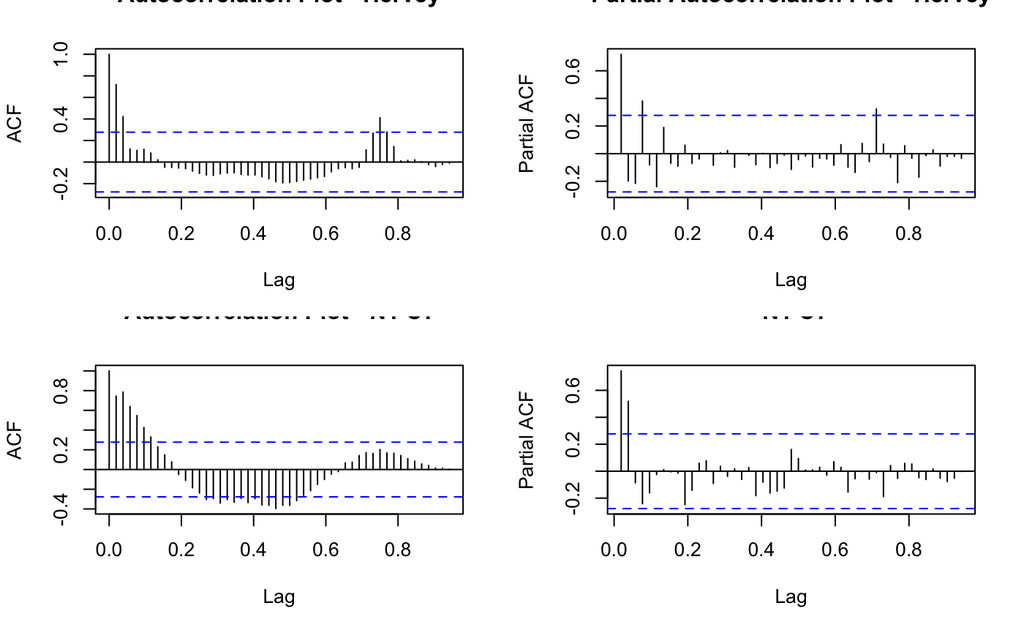

```r
# acf N1 Cт time series
stackOverflowts2[, c("N1 Cт")] %>%
  acf(lag.max = 300,
      main = "Autocorrelation Plot - N1 Cт")

# pacf N1 Cт time series
stackOverflowts2[, c("N1 Cт")] %>%
  pacf(lag.max = 300,
       main = " N1 Cт")
```

```r
stackoverflow_NN1 <- JT_dt %>%
  dplyr::select(Date,`N1 Cт`, CaseRate)
stackoverflow_NN1<-stackoverflow_NN1[complete.cases(stackoverflow_NN1),]#cleaning data

stackOverflowts3 <- ts(data = stackoverflow_NN1[, c("CaseRate","N1 Cт")], # selecting 2 variables
                       start = c(2021, 04), # start date
                       end = c(2022, 1), # end date
                       frequency = 52)
par(mfrow = c(2, 2))
# acf `NW/John T.` time series
stackOverflowts3[, c("CaseRate")] %>%
  acf(lag.max = 300,
      main = "Autocorrelation Plot - Infection Rate")

# pacf  `NW/John T.` time series
stackOverflowts3[, c("CaseRate")] %>%
  pacf(lag.max = 300,
       main = "Partial Autocorrelation Plot - Infection Rate")
```

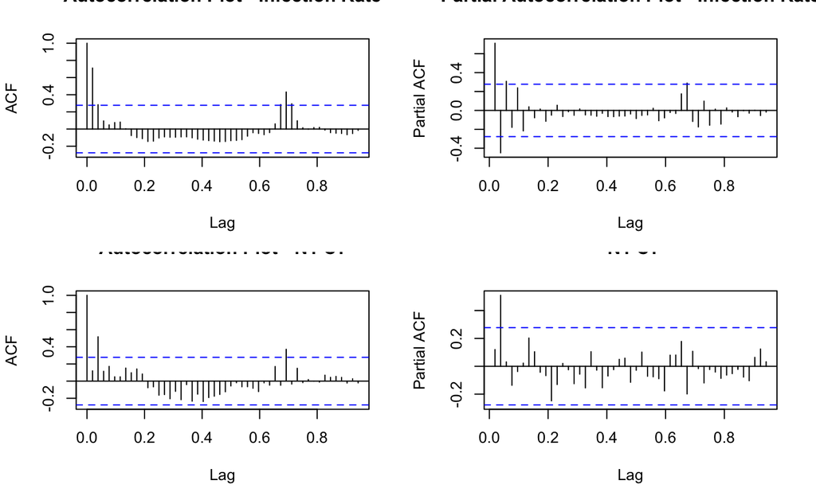

```r
# acf N1 Cт time series
stackOverflowts3[, c("N1 Cт")] %>%
  acf(lag.max = 300,
      main = "Autocorrelation Plot - N1 Cт")

# pacf N1 Cт time series
stackOverflowts3[, c("N1 Cт")] %>%
  pacf(lag.max = 300,
       main = " N1 Cт")
```

Kehe - I think cross-correlation may help us identify the leading time when virus in WW started to show a pikes before the cases were increasing.

```r
N1_ts <- ts(FH_dt$`N1 Cт`, frequency=365, start=c(year(minday1), as.numeric(format(minday1, "%j"))))
case_ts <- ts(case_all$ncase_7d_avg, frequency=365, start=c(year(minday2), as.numeric(format(minday2, "%j"))))

## intersection (only overlapping times)
dat_int <- ts.intersect(test_ts, case_ts)
## plot the ts
plot(dat_int, main = "Time Series Plot of Testing and Infection", yax.flip = TRUE)
```

[output not shown]